# Datasets from UCDP and PRIO

Joe Hasell

24/02/2022

*NB This notebook isn’t yet finished. I’m, half way re-organising it and switching over to the UCDP API where possible.*

# Functions used later

### Query UCDP API

There are usage limits on the UCDP API. This function splits a query into pages and then binds the sequential results into a single dataframe.

```r
query_UCDP<- function(resource, version, pagesize){

##e.g.:
# resource<- "battledeaths"
# version<- "21.1"
# pagesize<- "1000" # This is the max number of rows per query


this_page<- 0 # This will iterate to query individual pages
total_pages<- 1 # Just an initial value (consistent with the 'while' condition in the first round of the loop). Upon the first request, this will change to the total number of pages in the response from the API)

results_list<- list() # List to store results

# Loop over all pages
while (this_page + 1 <= total_pages)
{

# Build query
query<- paste0("https://ucdpapi.pcr.uu.se/api/",
               resource, "/",
               version,
               "?pagesize=", pagesize,
               "&page=", this_page)

# Make query
JSON_this_page<- fromJSON(query)

# Store the data bit of the JSON object in the list
results_list[[as.character(this_page)]]<- JSON_this_page[["Result"]]

# Grab the total number of pages (in order to end the query)
total_pages<- JSON_this_page[["TotalPages"]]

print(paste0("Page ", this_page + 1, " of ", total_pages, " has been read in."))

this_page<- this_page + 1

}

# Stack results (currently in list) into a single dataframe
df_results_all_pages<- bind_rows(results_list)

return(df_results_all_pages)

}
```

### Split rows

Some of the UCDP datasets code a ‘region’ (see discussion of location later on). Generally a conflict-year only has one region, but occasionally there are multiple regions, comma-separated. This function helps handle these cases. It takes each row of data where there are multiple regions, duplicates the row according to the number of regions indicated, and assigns one of the regions to each duplicate row. (I wrote it to also have the option for splitting out e.g. deaths evenly across regions, but in practice we’re not going to use this - instead we will rely on the geospatial data for deaths).

```r
split_rows<- function (df, sep, var_to_split, vars_to_share){

  # E.g.:
  # df<- df_one_sided
  # sep<- ", "
  # var_to_split<- "region"
  # vars_to_share<- c("best_fatality_estimate", "low_fatality_estimate", "high_fatality_estimate")

  # Separate out the multi-rows from the single-rows (as defined by the presence/absence of the separator character specified in the arguments)
  df_multi_rows<- df %>%
    filter(grepl(sep, eval(as.name(var_to_split))))

  df_single_rows<- df %>%
    filter(!grepl(sep, eval(as.name(var_to_split))))


 # make a list to store dataframes for each row that is being split
 multi_rows_split_list<- list()


 # for each row to be split make a new df with one row per value of the splitting variable, and dividing the 'vars_to_share' by the number of rows in which it will be split
 for(i in 1:nrow(df_multi_rows)) {

    # e.g.
    # i<- 1

    row <- df_multi_rows[i,]

    split_vector<- row %>%
    select(!!var_to_split) %>%
    as.character() %>%
    strsplit(sep) %>%
    unlist()

    # repeat the row x number of elements in the split var
    df_split_this_row <- row %>% slice(rep(1:n(), each = length(split_vector)))

    # drop the split var and append the split_vector as a column
    df_split_this_row<- df_split_this_row %>%
      select(-!!var_to_split) %>%
      mutate(!!var_to_split := split_vector)

    # Divide any 'to_share' vars by the length of the split vector
    if(missing(vars_to_share)) { # Check if this argument was supplied

    } else {

        for(v in vars_to_share){ #loop through each variable (given as string)

          df_split_this_row<- df_split_this_row %>%
            mutate(!!v := eval(as.name(v))/length(split_vector))

        }
    }

  # add the dataframe to the running list
 multi_rows_split_list[[as.character(i)]]<- df_split_this_row

}

 # Combine all the dataframes together
df_multi_rows_split<- bind_rows(multi_rows_split_list)

# Add the single-rows data back in.
df_singlefied_rows<- rbind(df_multi_rows_split, df_single_rows)

return(df_singlefied_rows)

}
```

### Summary

This outputs a simple summary - min, max and count NA - across a specified range of variables (or all variables if not specified).

```r
min_max_na_count_for_vars<- function(df, var_list){

    # e.g.
  # df<- df_ged
  # var_list<- c("year","deaths_best", "deaths_low", "deaths_high","type", "country_id")

  # If var_list argument is empty, summarise all variables
  if(missing(var_list)){
    var_list<- names(df)
  }

  # min values
  df_mins<- df %>%
  summarise_at(var_list, min)

  # max values
  df_maxs<- df %>%
  summarise_at(var_list, max)

  # NA count
  na_count <- df %>%
  select_(.dots = var_list) %>%
           summarise_all(funs(sum(is.na(.))))

  df_data_check<- bind_rows(df_mins,df_maxs, na_count )

  row.names(df_data_check) <- c("Min", "Max", "NA_count")


  return(df_data_check)

}
```

# Summary of the different datasets released by UCDP/PRIO

At the same time tidy and standardise so as to allow easier wrangling and analysis later on.

## UCDP Georeferenced Event Dataset (GED) Global

####Pull in and inspect

Note the georeferenced data is very large. Grabbing the data from the API can take even 30 mins or so. As an alternative, I provide a copy zipped of the data.

```r
# from zipfile

# With country mapping
df_ged<-  read.csv(unz("manipulation/ucdp_with_country.csv.zip", "ucdp_with_country.csv"))

# df_ged_orig<- read.csv(unz("original/ged211.csv.zip", "ged211.csv"))


# # from API - takes up to 30 mins and is unstable. Not recommended!
# # API query parameters
# resource<- "gedevents"
# version<- "21.1"
# pagesize<- "1000" # This is the max number of rows per query UCDP allows
#
# # Query API
# df_ged<- query_UCDP(resource, version, pagesize)

kable(head(df_ged))
```

| index | id | relid | year | active_year | code_status | type_of_violence | conflict_dset_id | conflict_new_id | conflict_name | dyad_dset_id | dyad_new_id | dyad_name | side_a_dset_id | side_a_new_id | side_a | side_b_dset_id | side_b_new_id | side_b | number_of_sources | source_article | source_office | source_date | source_headline | source_original | where_prec | where_coordinates | where_description | adm_1 | adm_2 | … |
| --- | --- | --- | --- | --- | --- | --- | --- | --- | --- | --- | --- | --- | --- | --- | --- | --- | --- | --- | --- | --- | --- | --- | --- | --- | --- | --- | --- | --- | --- | --- |
| 0 | 244657 | IRQ-2017-1-524-322 | 2017 | 1 | Clear | 1 | 259 | 259 | Iraq: Government | 524 | 524 | Government of Iraq - IS | 116 | 116 | Government of Iraq | 234 | 234 | IS | 3 | “Agence France Presse,2017-08-01,Attackers target Shiite mosque in Afghanistan’s Herat”;“Agence France Presse,2017-08-01,At least 20 killed in Shiite mosque attack in Afghanistan’s Herat”;“Pajhwok New… | Agence France Presse;Agence France Presse;Pajhwok News | 2017-08-01;2017-08-01;2017-07-31 | Attackers target Shiite mosque in Afghanistan’s Herat;At least 20 killed in Shiite mosque attack in Afghanistan’s Herat;Assailants among 6 killed in Iraq Embassy attack | IS, interior ministry, security source | 1 | Kabul city | Iraqi embassy in Kabul | Kabul province | Kabul district | … |
| 1 | 132140 | AFG-1989-1-411-2 | 1989 | 1 | Clear | 1 | 333 | 333 | Afghanistan: Government | 724 | 724 | Government of Afghanistan - Jam’iyyat-i Islami-yi Afghanistan | 130 | 130 | Government of Afghanistan | 292 | 292 | Jam’iyyat-i Islami-yi Afghanistan | -1 | The Times 13 Jan 1989 “Missiles and tea breaks for rebels;Afghanistan |  |  |  | Rebel source | 4 | Nangarhar province | Nangarhar province | Nangarhar province |  | … |
| 2 | 130364 | AFG-1989-1-411-37 | 1989 | 1 | Clear | 1 | 333 | 333 | Afghanistan: Government | 724 | 724 | Government of Afghanistan - Jam’iyyat-i Islami-yi Afghanistan | 130 | 130 | Government of Afghanistan | 292 | 292 | Jam’iyyat-i Islami-yi Afghanistan | -1 | R 18 Jan 1989 “KABUL REPORTS HUNDREDS OF REBEL CASUALTIES IN KUNDUZ PROVINCE. |  |  |  | Kabul radio (monitored in Islamabad) | 4 | Kunduz province | Kunduz province | Kunduz province |  | … |
| 3 | 130359 | AFG-1989-1-411-4 | 1989 | 1 | Clear | 1 | 333 | 333 | Afghanistan: Government | 724 | 724 | Government of Afghanistan - Jam’iyyat-i Islami-yi Afghanistan | 130 | 130 | Government of Afghanistan | 292 | 292 | Jam’iyyat-i Islami-yi Afghanistan | -1 | Reuters 24 Jan 1989 “AFGHANS KILL NEARLY 400 REBELS, TASS SAYS.” /The Washington Post 27 Jan 1989 “Rebels Send Food Convoy To Kabul;U.S. Orders Embassy Evacuated, Closed” /The Toronto Star 28 Jan 1989… |  |  |  | Tass news agency /Western diplomats quoting witnesses /Rebel spokesman | 1 | Salang pass | Salang pass (on the main highway linking Kabul with the Soviet border) | Baghlan province | Khinjan district | … |
| 4 | 133883 | AFG-1989-1-411-39 | 1989 | 1 | Clear | 1 | 333 | 333 | Afghanistan: Government | 724 | 724 | Government of Afghanistan - Jam’iyyat-i Islami-yi Afghanistan | 130 | 130 | Government of Afghanistan | 292 | 292 | Jam’iyyat-i Islami-yi Afghanistan | -1 | The Sunday Times 5 Feb 1989 “The Russians move out…;Withdrawal from Afghanistan |  |  |  | Military spokesman | 1 | Kabul city | Kabul city | Kabul province | Kabul district | … |
| 5 | 133874 | AFG-1989-1-411-6 | 1989 | 1 | Clear | 1 | 333 | 333 | Afghanistan: Government | 724 | 724 | Government of Afghanistan - Jam’iyyat-i Islami-yi Afghanistan | 130 | 130 | Government of Afghanistan | 292 | 292 | Jam’iyyat-i Islami-yi Afghanistan | -1 | St. Louis Post-Dispatch 1 Feb 1989 “JET CARRYING U.S. ENVOYS NEARLY HITS SOVIET PLANE |  |  |  | Rebel spokesman | 2 | Salang tunnel | Salang tunnel (near, villages near the main Soviet withdrawal route, Salang tunnel) | Baghlan province | Khinjan district | … |

Select needed vars, standardize var names and types

```r
df_ged_clean<- df_ged %>%
  rename(conflict_id = conflict_new_id,
         dyad_id = dyad_new_id,
         deaths_best = best,
         deaths_high = high,
         deaths_low = low,
         type = type_of_violence,
         event_id = id) %>%
  select(year, conflict_id, dyad_id, deaths_best, deaths_high, deaths_low, type, event_id)
```

#### Check structure and sanity check

Summary of the main vars

```r
min_max_na_count_for_vars(df_ged_clean)
```

```
##          year conflict_id dyad_id deaths_best deaths_high deaths_low type
## Min      1989         205     406           0           0          0    1
## Max      2020       15263   16692       48183       75000      48183    3
## NA_count    0           0       0           0           0          0    0
##          event_id
## Min             4
## Max        390297
## NA_count        0
```

The data is organised by ‘event’ (i.e. a particular raid or attack). These are associated to conflicts and dyads (a pair of opposing parties).

Verify that there are no duplicate year-event observations

```r
any(

  df_ged_clean %>%
        select(year, event_id) %>%
        duplicated()

)
```

```
## [1] FALSE
```

Conflicts have many events.

```r
kable(

     df_ged_clean %>%
        group_by(conflict_id) %>%
        summarise(number_of_events_per_conflict = n_distinct(event_id)) %>%
       head()

)
```

| conflict_id | number_of_events_per_conflict |
| --- | --- |
| 205 | 72 |
| 209 | 1842 |
| 218 | 1049 |
| 220 | 1 |
| 221 | 378 |
| 222 | 132 |

Note that conflicts never have more than one type.

```r
kable(

  df_ged_clean %>%
  group_by(conflict_id) %>%
  summarise(number_of_types = n_distinct(type)) %>%
  count(number_of_types)

)
```

| number_of_types | n |
| --- | --- |
| 1 | 1289 |

Note that there are a bunch of observations where the ‘best’ deaths estimate does not lie in the (closed) interval between low and high estimates….

```r
kable(
  head(
  df_ged_clean %>%
    filter(!(deaths_best >= deaths_low & deaths_best <= deaths_high))
  )
)
```

| year | conflict_id | dyad_id | deaths_best | deaths_high | deaths_low | type | event_id |
| --- | --- | --- | --- | --- | --- | --- | --- |
| 1990 | 333 | 726 | 136 | 135 | 136 | 1 | 134354 |
| 1993 | 333 | 726 | 53 | 33 | 53 | 1 | 145886 |
| 1995 | 333 | 726 | 2 | 1 | 2 | 1 | 146345 |
| 1989 | 333 | 727 | 22 | 21 | 0 | 1 | 133990 |
| 1989 | 333 | 727 | 85 | 84 | 0 | 1 | 134076 |
| 1989 | 333 | 732 | 21 | 0 | 21 | 1 | 186176 |

- including some where the high estimate is lower than the low estimate.

```r
kable(
  head(
  df_ged_clean %>%
    filter(deaths_low > deaths_high)
  )
)
```

| year | conflict_id | dyad_id | deaths_best | deaths_high | deaths_low | type | event_id |
| --- | --- | --- | --- | --- | --- | --- | --- |
| 1990 | 333 | 726 | 136 | 135 | 136 | 1 | 134354 |
| 1993 | 333 | 726 | 53 | 33 | 53 | 1 | 145886 |
| 1995 | 333 | 726 | 2 | 1 | 2 | 1 | 146345 |
| 1989 | 333 | 732 | 21 | 0 | 21 | 1 | 186176 |
| 2008 | 333 | 735 | 8 | 7 | 8 | 1 | 133321 |
| 2009 | 333 | 735 | 2 | 1 | 2 | 1 | 166092 |

#### Fix for high/low deaths

Separate out rows where low>high, swap high for low, and then bind back together.

```r
nonsense_deaths_low_high<- df_ged_clean %>%
    filter(deaths_low > deaths_high)

df_ged_clean_diff<- df_ged_clean %>%
    filter(deaths_low <= deaths_high)


nonsense_deaths_low_high<- nonsense_deaths_low_high %>%
  rename(deaths_low = deaths_high,
         deaths_high = deaths_low)

df_ged_clean<- rbind(df_ged_clean_diff, nonsense_deaths_low_high)
```

If best deaths est is higher than high, reset high to best.

```r
df_ged_clean<- df_ged_clean %>%
  mutate(deaths_high = if_else(deaths_best>deaths_high,
                               deaths_best,
                               deaths_high))
```

If best is lower than low, reset low to best.

```r
df_ged_clean<- df_ged_clean %>%
  mutate(deaths_low = if_else(deaths_best<deaths_low,
                               deaths_best,
                               deaths_low))
```

#### Aggregate

Aggregate deaths and number of conflicts by year and conflict type.

For the time being I will only make a World entity (when we have worked out how to map the lat/long coordinates to countries, I will aggregate by country and region.

```r
df_ged_agg_deaths_world<- df_ged_clean %>%
  group_by(year, type) %>%
  summarise(deaths_best = sum(deaths_best),
            deaths_low = sum(deaths_low),
            deaths_high = sum(deaths_high))
```

```
## argument.
```

```r
df_ged_active_conflicts_world<- df_ged_clean %>%
  group_by(year, conflict_id,type) %>%
  summarise(conflict_year_deaths = sum(deaths_best)) %>%
  filter(conflict_year_deaths>=25) %>%
  group_by(year, type) %>%
  summarise(number_of_conflicts = n_distinct(conflict_id))
df_ged_agg_world<- full_join(df_ged_agg_deaths_world, df_ged_active_conflicts_world) %>%
  mutate(entity = "World")
```

Pull together the world, region and country level aggregations.

```r
# Currently we only have the world aggregations
df_ged_agg<- bind_rows(df_ged_agg_world)
```

And I’ll add an “All types of violence” aggregate that sums across the three types of violence.

```r
# add 'all' type = 999

df_ged_agg_all_types<- df_ged_agg %>%
  group_by(year, entity) %>%
  summarise_all(sum) %>%
  mutate(type = 999)

df_ged_agg<- rbind(df_ged_agg, df_ged_agg_all_types)
```

#### Prepare for OWID grapher upload

Create meaningful variable names

Add type of violence labels

```r
df_ged_agg<- df_ged_agg %>%
  mutate(type_label = case_when(
    type == 1 ~ "state-based conflicts",
    type == 2 ~ "non-state conflicts",
    type == 3 ~ "one-sided violence",
    type == 999 ~ "all types of conflict and organized violence"
  ))
```

Pivot to long format creating a meaningful title for each variable

```r
df_ged_agg_long<- df_ged_agg %>%
  pivot_longer(cols = c(deaths_best, deaths_low, deaths_high, number_of_conflicts), names_to="varname") %>%
  mutate(new_varname = case_when(
    varname == "number_of_conflicts" & type %in% c(1,2) ~ paste0("Number of ", type_label),
    varname == "number_of_conflicts" & type %in% c(3,999) ~ paste0("Number of instances of ", type_label),
    varname == "deaths_best" ~ paste0("Deaths in ", type_label, " (best estimate)"),
    varname == "deaths_low" ~ paste0("Deaths in ", type_label, " (low estimate)"),
    varname == "deaths_high" ~ paste0("Deaths in ", type_label, " (high estimate)")
  )) %>%
  select(year, entity, value, new_varname)
```

Spread to wide format

```r
df_ged_agg_final<- df_ged_agg_long %>%
  pivot_wider(names_from = new_varname,
              values_from = value)
```

## A trio of datasets for the period since 1989, one for each conflict type

### UCDP Battle-Related Deaths Dataset (1989 onwards)

State-based (See codebook: https://ucdp.uu.se/downloads/brd/ucdp-brd-codebook-211.pdf)

```r
# API query parameters
resource<- "battledeaths"
version<- "21.1"
pagesize<- "1000" # This is the max number of rows per query UCDP allows

# Query API
df_brd<- query_UCDP(resource, version, pagesize)
```

```
## [1] "Page 1 of 2 has been read in."
## [1] "Page 2 of 2 has been read in."
```

Select needed vars, standardize var names and types.

```r
df_brd_clean<- df_brd %>%
  mutate(year = as.integer(year),
         conflict_id = as.integer(conflict_id),
         dyad_id = as.integer(dyad_id),
         deaths_best = as.integer(bd_best),
         deaths_high = as.integer(bd_high),
         deaths_low = as.integer(bd_low),
         type_statebased = as.integer(type_of_conflict)) %>%
  select(year, conflict_id, dyad_id, deaths_best, deaths_high, deaths_low, type_statebased)
```

####Structure The data is organised by year and dyad (i.e. the pair of participants fighting).

Check if there are any year-dyad duplicate observations

```r
any(

  df_brd_clean %>%
        select(year, dyad_id) %>%
        duplicated()

)
```

```
## [1] FALSE
```

There are, however, some conflicts with more than one dyad fighting.

```r
kable(

     df_brd_clean %>%
        select(year, dyad_id, conflict_id) %>%
        group_by(year, conflict_id) %>%
        summarise(number_of_dyads_per_conflict = n()) %>%
        group_by(number_of_dyads_per_conflict) %>%
        summarise(frequency = n())

)
```

```
## argument.
```

| number_of_dyads_per_conflict | frequency |
| --- | --- |
| 1 | 1074 |
| 2 | 194 |
| 3 | 56 |
| 4 | 12 |
| 5 | 4 |
| 6 | 1 |

####Sanity check Note that there are a bunch of observations where the ‘best’ deaths estimate does not lie in the (closed) interval between low and high estimates….

```r
kable(
  head(
    df_brd_clean %>%
    filter(!(deaths_best >= deaths_low & deaths_best <= deaths_high))
  )
)
```

| year | conflict_id | dyad_id | deaths_best | deaths_high | deaths_low | type_statebased |
| --- | --- | --- | --- | --- | --- | --- |
| 2013 | 13042 | 13821 | 78 | 77 | 63 | 3 |
| 2012 | 234 | 477 | 197 | 207 | 198 | 3 |
| 1999 | 335 | 740 | 32 | 38 | 38 | 3 |
| 1998 | 352 | 776 | 3762 | 4420 | 3763 | 3 |
| 1998 | 354 | 781 | 1952 | 2038 | 1953 | 3 |
| 2018 | 364 | 792 | 386 | 391 | 387 | 3 |

Check min, max and count NAs. (Note that 25 deaths min is a defintional thing - for a conflict to be counted by UCDP as ‘live’ in a given year there must have been at least 25 deaths)

```r
kable(
min_max_na_count_for_vars(df_brd_clean)
)
```

|  | year | conflict_id | dyad_id | deaths_best | deaths_high | deaths_low | type_statebased |
| --- | --- | --- | --- | --- | --- | --- | --- |
| Min | 1989 | 205 | 406 | 25 | 25 | 0 | 2 |
| Max | 2020 | 15183 | 16562 | 69922 | 73459 | 66957 | 4 |
| NA_count | 0 | 0 | 0 | 0 | 0 | 0 | 0 |

### UCDP Non-State Conflict Dataset (1989 onwards)

Non-state (See codebook: https://ucdp.uu.se/downloads/nsos/ucdp-nonstate-211.pdf)

```r
# API query parameters
resource<- "nonstate"
version<- "21.1"
pagesize<- "1000" # This is the max number of rows per query UCDP allows

# Query API
df_non_state<- query_UCDP(resource, version, pagesize)
```

```
## [1] "Page 1 of 2 has been read in."
## [1] "Page 2 of 2 has been read in."
```

```r
kable(head(df_non_state))
```

| conflict_id | dyad_id | org | side_a_name | side_a_name_fulltext | side_a_name_mothertongue | side_a_id | side_a_components | side_a_2nd | gwno_a_2nd | side_b_name | side_b_name_fulltext | side_b_name_mothertongue | side_b_id | side_b_components | side_b_2nd | gwno_b_2nd | start_date | start_prec | start_date2 | start_prec2 | ep_end | ep_end_date | ep_end_prec | year | best_fatality_estimate | low_fatality_estimate | high_fatality_estimate | location | gwno_location | … |
| --- | --- | --- | --- | --- | --- | --- | --- | --- | --- | --- | --- | --- | --- | --- | --- | --- | --- | --- | --- | --- | --- | --- | --- | --- | --- | --- | --- | --- | --- | --- |
| 10066 | 10676 | 1 | Hizb-i Wahdat | Unity Party | Hizb-i Wahdat | 300 |  |  |  | Junbish-i Milli-yi Islami | National Islamic Movement | Junbish-i Milli-yi Islami | 302 |  |  |  | 1995-02-20 | 2 | 1998-03-15 | 2 | 1 | 1998-03-19 | 1 | 1998 | 101 | 101 | 101 | Afghanistan | 700 | … |
| 10072 | 10682 | 1 | Forces of Sayed Mansur Naderi | Forces of Sayed Mansur Naderi | Forces of Sayed Mansur Naderi | 2518 |  |  |  | Hizb-i Islami-yi Afghanistan | Islamic Party of Afghanistan | Hizb-i Islami-yi Afghanistan | 299 |  |  |  | 1995-09-30 | 3 | 1995-10-29 | 1 | 1 | 1995-10-29 | 1 | 1995 | 40 | 40 | 40 | Afghanistan | 700 | … |
| 10289 | 10899 | 1 | NSCN-K | National Socialist Council of Nagaland- Khaplang faction | n/a | 224 |  |  |  | NSCN-K-K | National Socialist Council of Nagaland-Khole-Kitovi Faction | n/a | 2430 |  |  |  | 2011-12-22 | 1 | 2012-06-19 | 1 | 1 | 2012-12-17 | 1 | 2012 | 54 | 52 | 54 | India | 750 | … |
| 10310 | 10920 | 3 | Han Chinese | Han Chinese | Han Chinese | 2460 |  |  |  | Uighur | Uighur | Uighur | 2461 |  |  |  | 2009-06-26 | 1 | 2009-07-07 | 2 | 1 | 2009-07-07 | 2 | 2009 | 187 | 187 | 683 | China | 710 | … |
| 10444 | 11054 | 3 | Buddhists (Myanmar) | Buddhists (Myanmar) | Buddhists (Myanmar) | 2698 |  |  |  | Muslims (Myanmar) | Muslims (Myanmar) | Muslims (Myanmar) | 2699 |  |  |  | 2001-02-16 | 3 | 2001-02-28 | 3 | 1 | 2001-05-23 | 2 | 2001 | 37 | 22 | 40 | Myanmar (Burma) | 775 | … |
| 10444 | 11054 | 3 | Buddhists (Myanmar) | Buddhists (Myanmar) | Buddhists (Myanmar) | 2698 |  |  |  | Muslims (Myanmar) | Muslims (Myanmar) | Muslims (Myanmar) | 2699 |  |  |  | 2001-02-16 | 3 | 2012-06-13 | 2 | 0 |  |  | 2012 | 134 | 124 | 160 | Myanmar (Burma) | 775 | … |

Select needed vars, standardize var names and types.

```r
df_non_state_clean<- df_non_state %>%
  mutate(year = as.integer(year),
         conflict_id = as.integer(conflict_id),
         dyad_id = as.integer(dyad_id),
         deaths_best = as.integer(best_fatality_estimate),
         deaths_high = as.integer(high_fatality_estimate),
         deaths_low = as.integer(low_fatality_estimate)) %>%
  select(year, conflict_id, dyad_id, deaths_best, deaths_high, deaths_low)
```

####Structure The data is organised by year and conflict.

Check if there are any year-conflict duplicate observations

```r
any(

  df_non_state_clean %>%
        select(year, conflict_id) %>%
        duplicated()

)
```

```
## [1] FALSE
```

In any case there is only ever one conflict per dyad, so the structure is basically the same as BRD

```r
kable(

     df_non_state_clean %>%
        select(year, dyad_id, conflict_id) %>%
        group_by(year, dyad_id) %>%
        summarise(number_of_conflicts_per_dyad = n()) %>%
        group_by(number_of_conflicts_per_dyad) %>%
        summarise(frequency = n())

)
```

```
## argument.
```

| number_of_conflicts_per_dyad | frequency |
| --- | --- |
| 1 | 1356 |

####Sanity check Note that there are a bunch of observations where the ‘best’ deaths estimate does not lie in the (closed) interval between low and high estimates….

```r
kable(
  head(
  df_non_state_clean %>%
    filter(!(deaths_best >= deaths_low & deaths_best <= deaths_high))
  )
)
```

| year | conflict_id | dyad_id | deaths_best | deaths_high | deaths_low |
| --- | --- | --- | --- | --- | --- |
| 2015 | 13744 | 14813 | 934 | 899 | 873 |
| 2018 | 14285 | 15489 | 2337 | 2338 | 2338 |
| 2018 | 14456 | 15717 | 562 | 560 | 562 |
| 2019 | 14542 | 15819 | 97 | 92 | 97 |
| 2018 | 14808 | 16141 | 118 | 288 | 124 |
| 2003 | 4601 | 5211 | 35 | 41 | 41 |

- including some where the high estimate is lower than the low estimate.

```r
kable(
  head(
  df_non_state_clean %>%
    filter(deaths_low > deaths_high)
  )
)
```

| year | conflict_id | dyad_id | deaths_best | deaths_high | deaths_low |
| --- | --- | --- | --- | --- | --- |
| 2018 | 14456 | 15717 | 562 | 560 | 562 |
| 2019 | 14542 | 15819 | 97 | 92 | 97 |

Check min, max and count NAs. (Note that 25 deaths min is a defintional thing - for a conflict to be counted by UCDP as ‘live’ in a given year there must have been at least 25 deaths)

```r
kable(
min_max_na_count_for_vars(df_non_state_clean)
)
```

|  | year | conflict_id | dyad_id | deaths_best | deaths_high | deaths_low |
| --- | --- | --- | --- | --- | --- | --- |
| Min | 1989 | 4564 | 5174 | 25 | 25 | 0 |
| Max | 2020 | 15263 | 16692 | 8762 | 10870 | 8279 |
| NA_count | 0 | 0 | 0 | 0 | 0 | 0 |

### UCDP One-sided Violence Dataset (1989 onwards)

```r
# API query parameters
resource<- "onesided"
version<- "21.1"
pagesize<- "1000" # This is the max number of rows per query UCDP allows

# Query API
df_one_sided<- query_UCDP(resource, version, pagesize)
```

```
## [1] "Page 1 of 2 has been read in."
## [1] "Page 2 of 2 has been read in."
```

```r
kable(head(df_one_sided))
```

| conflict_id | dyad_id | actor_id | coalition_components | actor_name | actor_name_fulltext | actor_name_mothertongue | year | best_fatality_estimate | low_fatality_estimate | high_fatality_estimate | is_government_actor | location | gwno_location | gwnoa | region | version |
| --- | --- | --- | --- | --- | --- | --- | --- | --- | --- | --- | --- | --- | --- | --- | --- | --- |
| 641 | 1108 | 10 |  | Government of Mexico | Government of Mexico | n/a | 2014 | 32 | 32 | 36 | 1 | Mexico | 70 | 70 | 5 | 21.1 |
| 700 | 1167 | 100 |  | Government of Mozambique | Government of Mozambique | n/a | 2020 | 110 | 69 | 143 | 1 | Mozambique | 541 | 541 | 4 | 21.1 |
| 476 | 943 | 101 |  | Government of Zimbabwe (Rhodesia) | Government of Rhodesia | n/a | 2008 | 253 | 253 | 317 | 1 | Zimbabwe (Rhodesia) | 552 | 552 | 4 | 21.1 |
| 477 | 944 | 102 |  | Government of South Africa | Government of South Africa | n/a | 1989 | 57 | 57 | 388 | 1 | Kingdom of eSwatini (Swaziland), Namibia, South Africa | 560, 565, 572 | 560 | 4 | 21.1 |
| 477 | 944 | 102 |  | Government of South Africa | Government of South Africa | n/a | 1990 | 195 | 195 | 218 | 1 | Botswana, South Africa | 560, 571 | 560 | 4 | 21.1 |
| 477 | 944 | 102 |  | Government of South Africa | Government of South Africa | n/a | 1991 | 49 | 49 | 62 | 1 | South Africa | 560 | 560 | 4 | 21.1 |

Select needed vars, standardize var names and types.

```r
df_one_sided_clean<- df_one_sided %>%
  mutate(year = as.integer(year),
         conflict_id = as.integer(conflict_id),
         actor_id = as.integer(actor_id),
         dyad_id = as.integer(dyad_id),
         deaths_best = as.integer(best_fatality_estimate),
         deaths_high = as.integer(high_fatality_estimate),
         deaths_low = as.integer(low_fatality_estimate)) %>%
  select(year, conflict_id, actor_id, dyad_id, deaths_best, deaths_high, deaths_low)
```

####Structure The data is organised by year and actor

Check if there are any year-conflict duplicate observations

```r
any(

  df_one_sided_clean %>%
        select(year, actor_id) %>%
        duplicated()

)
```

```
## [1] FALSE
```

In any case there is only ever one actor per dyad, so the structure is basically the same as BRD: year-dyad.

```r
kable(

     df_one_sided_clean %>%
        select(year, dyad_id, actor_id) %>%
        group_by(year, dyad_id) %>%
        summarise(number_of_actors_per_dyad = n()) %>%
        group_by(number_of_actors_per_dyad) %>%
        summarise(frequency = n())

)
```

```
## argument.
```

| number_of_actors_per_dyad | frequency |
| --- | --- |
| 1 | 1060 |

####Sanity check Note that there are a bunch of observations where the ‘best’ deaths estimate does not lie in the (closed) interval between low and high estimates….

```r
kable(
  head(
  df_one_sided_clean %>%
    filter(!(deaths_best >= deaths_low & deaths_best <= deaths_high))
  )
)
```

| year | conflict_id | actor_id | dyad_id | deaths_best | deaths_high | deaths_low |
| --- | --- | --- | --- | --- | --- | --- |
| 2013 | 711 | 118 | 1178 | 2665 | 2640 | 2456 |
| 1994 | 649 | 21 | 1116 | 72 | 77 | 76 |
| 2016 | 573 | 539 | 1040 | 41 | 50 | 44 |
| 2016 | 9237 | 6590 | 15123 | 26 | 21 | 26 |
| 2001 | 605 | 743 | 1072 | 336 | 464 | 340 |

- including some where the high estimate is lower than the low estimate.

```r
kable(
  head(
  df_one_sided_clean %>%
    filter(deaths_low > deaths_high)
  )
)
```

| year | conflict_id | actor_id | dyad_id | deaths_best | deaths_high | deaths_low |
| --- | --- | --- | --- | --- | --- | --- |
| 2016 | 9237 | 6590 | 15123 | 26 | 21 | 26 |

Check min, max and count NAs. (Note that 25 deaths min is a defintional thing - for a conflict to be counted by UCDP as ‘live’ in a given year there must have been at least 25 deaths)

```r
kable(
min_max_na_count_for_vars(df_one_sided_clean)
)
```

|  | year | conflict_id | actor_id | dyad_id | deaths_best | deaths_high | deaths_low |
| --- | --- | --- | --- | --- | --- | --- | --- |
| Min | 1989 | 444 | 6 | 911 | 25 | 21 | 0 |
| Max | 2020 | 15226 | 7963 | 16653 | 531133 | 1298547 | 230491 |
| NA_count | 0 | 0 | 0 | 0 | 0 | 0 | 0 |

#### Join the three datasets and compare with the geospatial data

UCDP give a note that the different datasets are updated at different times so they might not be totally consistent with one another.

```r
post_1989_list<- list("BRD" = df_brd_clean,
                      "nonstate" = df_non_state_clean,
                      "onesided" = df_one_sided_clean)

df_all_three<- bind_rows(post_1989_list, .id = "dataset")
```

```r
df_all_three_agg<- df_all_three %>%
  group_by(year) %>%
  summarise(deaths_best = sum(deaths_best),
            deaths_high = sum(deaths_high),
            deaths_low = sum(deaths_low),
            number_of_conflicts = n_distinct(conflict_id))
```

Compare with georeferenced totals

```r
df_list<- list("GED" = df_ged_agg_all_types,
               "Non_GED" = df_all_three_agg)

compare<- bind_rows(df_list, .id = "data_source")
```

The deaths estimates are very close, but not exactly the same.

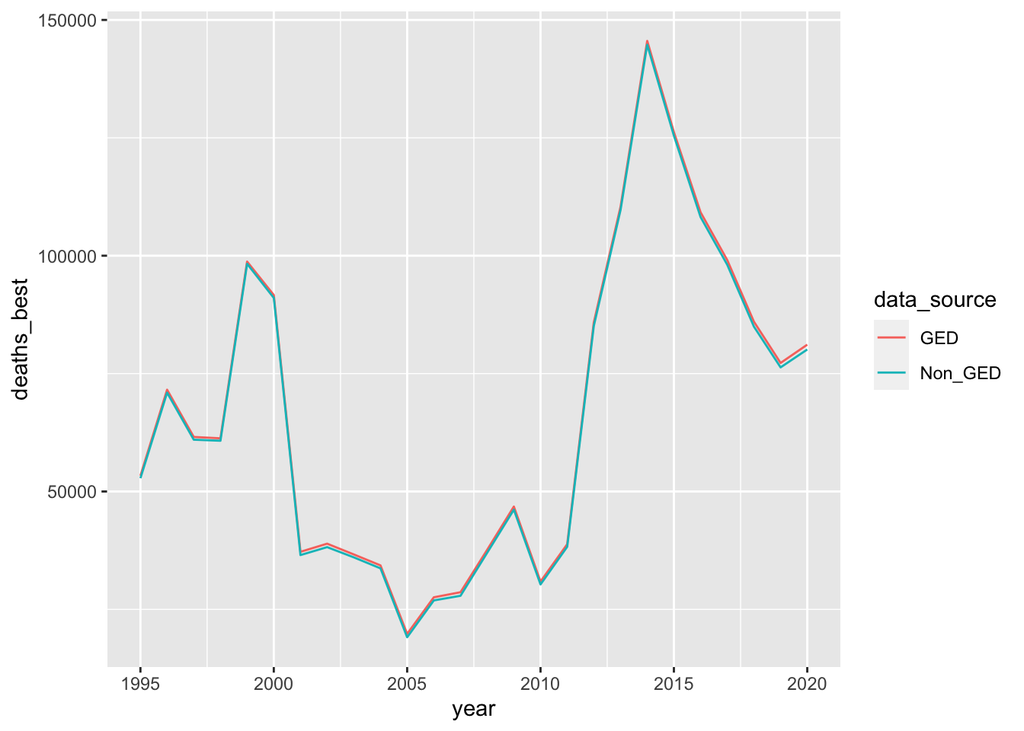

```r
compare %>%
  filter(year>1994) %>% # look after Rwandan genocide peak for a better view
  ggplot(aes(x = year, y = deaths_best, colour = data_source)) +
  geom_line()
```

And the number of conflicts is sometimes higher (by one or two conflicts) in the GED data

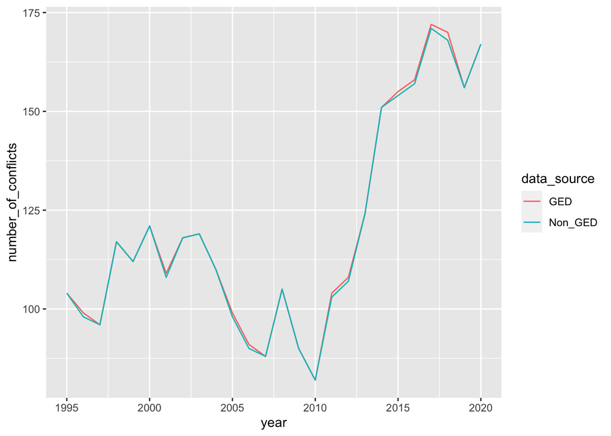

```r
compare %>%
  filter(year>1994) %>% # look after Rwandan genocide peak for a better view
  ggplot(aes(x = year, y = number_of_conflicts, colour = data_source)) +
  geom_line()
```

## UCDP/PRIO Armed Conflict Dataset (1946 onwards)

This doesn’t include any information about deaths. But we can use it to count the number of statebased conflicts, by region and type of conflict (type here refers to subtypes of statebased conflict).

```r
# API query parameters
resource<- "ucdpprioconflict"
version<- "21.1"
pagesize<- "1000" # This is the max number of rows per query UCDP allows

# Query API
df_acd<- query_UCDP(resource, version, pagesize)
```

```
## [1] "Page 1 of 3 has been read in."
## [1] "Page 2 of 3 has been read in."
## [1] "Page 3 of 3 has been read in."
```

```r
kable(head(df_acd))
```

| conflict_id | location | side_a | side_a_Id | side_a_2nd | side_b | side_b_Id | side_b_2nd | incompatibility | territory_name | year | intensity_level | cumulative_intensity | type_of_conflict | start_date | start_prec | start_date2 | start_prec2 | ep_end | ep_end_date | ep_end_prec | gwno_a | gwno_a_2nd | gwno_b | gwno_b_2nd | gwno_loc | region | version |
| --- | --- | --- | --- | --- | --- | --- | --- | --- | --- | --- | --- | --- | --- | --- | --- | --- | --- | --- | --- | --- | --- | --- | --- | --- | --- | --- | --- |
| 11342 | India | Government of India | 141 |  | GNLA | 1163 |  | 1 | Garoland | 2012 | 1 | 0 | 3 | 1997-05-29 | 1 | 2012-11-15 | 1 | 1 | 2012-12-21 |  | 750 |  |  |  | 750 | 3 | 21.1 |
| 11342 | India | Government of India | 141 |  | GNLA | 1163 |  | 1 | Garoland | 2014 | 1 | 0 | 3 | 1997-05-29 | 1 | 2014-07-01 | 1 | 1 | 2014-11-27 |  | 750 |  |  |  | 750 | 3 | 21.1 |
| 11343 | Egypt, Israel | Government of Egypt | 117 |  | Government of Israel | 121 |  | 1 | Suez/Sinai | 1967 | 2 | 1 | 2 | 1967-06-05 | 1 | 1967-06-05 | 1 | 1 | 1967-06-10 |  | 651 |  | 666 |  | 651, 666 | 2 | 21.1 |
| 11343 | Egypt, Israel | Government of Egypt | 117 |  | Government of Israel | 121 |  | 1 | Suez/Sinai | 1969 | 1 | 1 | 2 | 1967-06-05 | 1 | 1969-03-06 | 1 | 0 |  |  | 651 |  | 666 |  | 651, 666 | 2 | 21.1 |
| 11343 | Egypt, Israel | Government of Egypt | 117 |  | Government of Israel | 121 |  | 1 | Suez/Sinai | 1970 | 1 | 1 | 2 | 1967-06-05 | 1 | 1969-03-06 | 1 | 1 | 1970-08-07 |  | 651 |  | 666 |  | 651, 666 | 2 | 21.1 |
| 11343 | Egypt, Israel | Government of Egypt | 117 |  | Government of Israel | 121 |  | 1 | Suez/Sinai | 1973 | 2 | 1 | 2 | 1967-06-05 | 1 | 1973-10-06 | 1 | 1 | 1973-10-24 |  | 651 |  | 666 |  | 651, 666 | 2 | 21.1 |

Select needed vars, standardize var names and types.

```r
df_acd_clean<- df_acd %>%
  mutate(year = as.integer(year),
         conflict_id = as.integer(conflict_id),
         type_statebased = as.integer(type_of_conflict)) %>%
  select(year, conflict_id, type_statebased, region)
```

####Structure The data is organised by year and conflict.

Check if there are any year-conflict duplicate observations

```r
any(

  df_acd_clean %>%
        select(year, conflict_id) %>%
        duplicated()

)
```

```
## [1] FALSE
```

There are no NAs

```r
any(is.na(df_acd_clean))
```

```
## [1] FALSE
```

Summary of the variables of interest. Note that `region` is coded as a character var.

```r
summary(df_acd_clean)
```

```
##       year       conflict_id      type_statebased    region
##  Min.   :1946   Min.   :  200.0   Min.   :1.000   Length:2506
##  1st Qu.:1975   1st Qu.:  249.2   1st Qu.:3.000   Class :character
##  Median :1990   Median :  308.0   Median :3.000   Mode  :character
##  Mean   :1989   Mean   : 1190.9   Mean   :3.008
##  3rd Qu.:2006   3rd Qu.:  364.0   3rd Qu.:3.000
##  Max.   :2020   Max.   :15183.0   Max.   :4.000
```

Moreover, there are some observations with multiple regions (separated by a comma).

```r
kable(
  df_acd_clean %>%
    filter(grepl(",",region))
)
```

| year | conflict_id | type_statebased | region |
| --- | --- | --- | --- |
| 2001 | 13692 | 2 | 1, 3, 5 |
| 1946 | 214 | 2 | 1, 3 |
| 1951 | 239 | 2 | 1, 2 |
| 1952 | 239 | 2 | 1, 2 |
| 1956 | 252 | 2 | 1, 2 |
| 1961 | 272 | 2 | 1, 4 |
| 1962 | 276 | 2 | 1, 3 |
| 1969 | 305 | 2 | 1, 3 |
| 1974 | 323 | 2 | 1, 2 |
| 1982 | 346 | 2 | 1, 5 |
| 2003 | 420 | 2 | 1, 2, 3, 5 |
| 1979 | 431 | 2 | 1, 3 |

#### Aggregate

Aggregate to find the global number of state-based conflicts by conflict subtype.

```r
df_acd_agg_world_by_type<-  df_acd_clean %>%
  group_by(year, type_statebased) %>%
  summarise(number_of_conflicts = n_distinct(conflict_id)) %>%
  mutate(entity = "World")
```

```
## argument.
```

Find total for all types of conflict (code it as `type_statebased`=999 )

```r
df_acd_agg_world_all_types<-  df_acd_clean %>%
  group_by(year) %>%
  summarise(number_of_conflicts = n_distinct(conflict_id)) %>%
  mutate(entity = "World",
         type_statebased = 999)
```

Bind the different aggregate dfs together

```r
df_acd_agg_all_aggs<- bind_rows(df_acd_agg_world_by_type, df_acd_agg_world_all_types)
```

Years with zero conflicts of a particular type will just be missing from the above. Here I make a complete grid to fill in the zeros.

```r
years<- seq(from= min(df_acd_clean$year), to = max(df_acd_clean$year))
types<- c(1,2,3,4,999)

df_acd_agg<- expand.grid(years, types)

# rename columns as per actual data
names(df_acd_agg)<- c("year", "type_statebased")

# Merge in actual data
df_acd_agg<- left_join(df_acd_agg, df_acd_agg_all_aggs)
```

#### Prepare for OWID grapher

Add labels, and create meaningful variabl2 names

Spread to wide format.

## PRIO Battledeaths Dataset 3.1 (1946-2008)

```r
# from zipfile
df_prio_bd<- read.csv(unz("original/PRIO Battle Deaths Dataset 3.1.csv.zip", "PRIO Battle Deaths Dataset 3.1.csv"))
```

# Datasets we are constructing

## Deaths from all types of conflict and one-sided violence cince 1989.

## Battle-related (state-based) deaths since 1946,

-By region, by conlfict type.

# OLDER STUFF BELOW:

# Data since 1989

The aim is to get a dataset of total deaths by year, entity (country*, region, world), and type of violence.

UCDP provides two kinds of data that can be used here.

## The georeferenced data (by event-dyad)

The first is it’s ‘Georeferenced’ dataset, which is structured by event (each row relates a particular bombing or raid in a certain place).

See the codebook here: https://ucdp.uu.se/downloads/ged/ged211.pdf

For deaths the primary focus will be on the `best` column (which is “The best (most likely) estimate of total fatalities resulting from an event.”) But I will also prepare aggregate data for the `low` and `high` deaths estimates.

An advantage of this dataset is that the place where the event happened is coded (local, country and region level).

#### Note on countries

Because the dataset only includes events with deaths (not the absence of events), after aggregating we will me missing observations for countries/years where there were no conflict deaths. UCDP aims to be complete global coverage: “GED 21.1 is a global dataset that covers the world between 1989-01-01 and 2020-12-31.” So any country-years with no deaths in this dataset needs to be given an entry of zero, rather than NA.

It requires some care however to make sure that we’re using the same ‘state system’ as the data is coded in. (For instance we shouldn’t code a 0 for Ukraine in 1990 because it didn’t exist and is included in ‘Russia (Soviet Union)’).

I will use the `country_id` which refer to the Gleditsch and Ward (G&W) state system. I will then ‘fill in the blanks’ based on the G&W system, and only then convert to OWID entities.

Because of the urgency to update, for now I won’t do this step. I will just aggregate at the region and conflict type level. And then I will come back to add the country-level data.

[output not shown]

[output cut: 54 more lines]

# State-based conflict deaths since 1946

### Overview

To produce a series of conflict deaths since 1946 we will stitch together:

1. the UCDP Battle-Related Deaths Dataset (the ‘state-based’ component of the three non-georeferenced datasets from 1989 introduced above).
2. Earlier data for the same concept produced by PRIO that is no longer maintained.

UCDP’s BRD dataset is made to be compatible with the UCDP/PRIO Armed Conflict Dataset (ACD). The latter is a dataset just of conflicts that goes back to 1946, but does not include estimates of deaths. So the UCDP’s ‘state-based’ conflict death series from 1989 is a bit like a ‘bolt-on’ that adds deaths estimates onto the framework of conflicts produced in the ACD dataset.

UCDP does not maintain a dataset of conflict deaths prior to 1989.

However an older dataset of battle deaths that aimed to the same thing (for a much older version of the ACD data) was produced by PRIO with data available from 1946.

The problem is that 1) it is old (ends in 2008) 2) it is no longer being maintained (not since 2008) and 3) the conflict framework is now somewhat out of step with the latest ACD dataset (for instance there is a different conflict ID system).

Nonetheless in terms of total deaths in any given year, the older PRIO data is likely to be fairly complete an accurate for the years it covers, especially prior to 1989. (i.e. it seems safe to assume that not a lot of new information will have surfaced since 2008 about conflicts prior to 1989). So it’s reasonable to stitch these aggregate deaths from these two datasets together.

#### A note on location within these two (non-georeferenced) datasets

The same note on the way location variables are coded mentioned above applies to these two datasets.

In these datasets, the location variables (`location` and `region`) do not (necessarily) refer to the actual place where the deaths occurred. They refer to the location of the ‘incompatibility’ that delineates the conflict (i.e. an argument over territory or of who should be in charge of a place.)

Unlike the period since 1989, there is however there no alternative geo-referenced data to turn to.

We have to just handle this problem and explain it well in the metadata for the resulting OWID dataset.

For this reason we will only make use of `region` entities (since the issue will be less acute in the at the level of regions).

#### A note on conflict type

This data all falls into the ‘state-based’ type of violence, disucssed in relation to the 1989 data above.

But there is a sub-classification denoting whether it’s a civil conflict, imperial conflict etc. (The same classification is also used in the more recent UCDP BRD dataset).

### Wrangling

Pull in PRIO data (1946-2008)

```r
df_prio<- read.csv("original/PRIO/PRIO Battle Deaths Dataset 3.1.csv")
```

Rename a few variables to make matching to UCDP later more straightforward.

```r
df_prio<- df_prio %>%
  rename(bd_low = bdeadlow,
         bd_high = bdeadhig,
         bd_best = bdeadbes)
```

As before, the deaths variable we will use is the ‘best estimate’ But unlike the maintained UCDP datasets, this is sometimes coded as missing (`bd_best`=-999).

```r
browse_missing_best_estimates<- df_prio %>%
  filter(bd_best == -999)

kable(head(browse_missing_best_estimates))
```

```r
df_prio_check_missing<- df_prio %>%
  mutate(best_missing = if_else(bd_best == -999,
                                1,
                                0)) %>%
  mutate(high_estimate_bracket = cut(bd_high,
              breaks=c(0, 1000, 10000, 100000, max(df_prio$bd_high)),
              labels=c("<1K", "1K-10K", "10K-100K", ">100K")))


missing_best_deaths_est_by_range<- df_prio_check_missing %>%
  group_by(high_estimate_bracket, best_missing) %>%
  summarise(n=n()) %>%
  pivot_wider(names_from = "best_missing", values_from = "n") %>%
  mutate(share_missing = `1`/(`1` + `0`))

kable(missing_best_deaths_est_by_range)
```

Let’s take a look at some of those very big events with missing

```r
kable(df_prio_check_missing %>% filter(best_missing == 1, high_estimate_bracket == ">100K"))
```

Note that that’s some very large uncertainty that will make the series look materially different.

### Aggregate deaths at the year region and conflict type levels.

Let’s produce 3 different aggregations: 1) using the low deaths estimate always, 2) using the high deaths estimate always, 3) using the best estimate where available and the mid-point between low and high estimates where it is not available.

NB. in taking the midpoint this is different to how I’ve treated the dataset in the past - where I took the low estimate when no best estimate was available.

```r
# Add a column for 'best or else midpoint' deaths estimates
df_prio<- df_prio %>%
  mutate(bd_best_or_midpoint = if_else(bd_best == -999, (bd_low + bd_high)/2, as.numeric(bd_best)))

# Aggregate high, low and 'best or else midpoint' deaths estimates by year, region and conflict type
df_prio_agg<- df_prio %>%
  group_by(year, region, type) %>%
  summarise(bd_low = sum(bd_low),
            bd_high = sum(bd_high),
            bd_best_or_midpoint = sum(bd_best_or_midpoint))

# stack to long-format
df_prio_agg<- df_prio_agg %>%
  pivot_longer(cols =  c(bd_low, bd_high, bd_best_or_midpoint),
               names_to = "death_est_type",
               values_to = "deaths_estimate")
```

Because the data measures the presence (rather than absence) of conflict deaths, region-type-year observations will be missing where there were no conflict deaths. We want these included as zeros, rather than missing.

I make a complete set of region-type-year observations of zero, and then merge and replace in the actual data.

```r
regions <- unique(df_prio$region)
types <- unique(df_prio$type)
years <- seq(from=min(df_prio$year), to=max(df_prio$year))
death_est_type <- c("bd_low", "bd_high", "bd_best_or_midpoint")


# Calling expand.grid() Function to fill out all permutations
df_prio_agg_full<- expand.grid(years, types, regions, death_est_type)

# rename columns as per actual data
names(df_prio_agg_full)<- c("year", "type", "region", "death_est_type")

# # add zero deaths observation
# df_prio_agg_full<- df_prio_agg_full %>%
#   mutate(deaths_estimate = 0)

# merge in recorded aggregates from data and replace NA with zeros
df_prio_agg_full<- left_join(df_prio_agg_full, df_prio_agg) %>%
  mutate(deaths_estimate = replace_na(deaths_estimate, 0))
```

Give region and conflict type codes understandable labels

```r
df_prio_agg_full<- df_prio_agg_full %>%
 mutate(type = recode(type,
                  `1` = "Colonial or imperial conflicts", # Extrasystemic
                  `2` = "Conflicts between states", # interstate
                  `3` = "Civil conflicts", # intrastate
                  `4` = "Civil conflicts with foreign state intervention" #  internationalized intrastate
                 ))


df_prio_agg_full<- df_prio_agg_full %>%
 mutate(region = recode(region,
                  `1` = "Europe",
                  `2` = "Middle East",
                  `3` = "Asia & Oceania",
                  `4` = "Africa",
                  `5` = "Americas"
                 ))
```

Calculate aggregate ‘All state-based conflict types’ type and merge back in

```r
df_prio_agg_all_types<- df_prio_agg_full %>%
  group_by(year, death_est_type, region) %>%
  summarise(deaths_estimate = sum(deaths_estimate)) %>%
  mutate(type = "All state-based conflict types")

df_prio_agg_full<- rbind(df_prio_agg_full, df_prio_agg_all_types)
```

Calculate aggregate World entity and merge back in

```r
df_prio_agg_world<- df_prio_agg_full %>%
  group_by(year, death_est_type, type) %>%
  summarise(deaths_estimate = sum(deaths_estimate)) %>%
  mutate(region = "World")

df_prio_agg_full<- rbind(df_prio_agg_full, df_prio_agg_world)
```

Some plots to sense check

```r
df_prio_agg_full %>%
  filter(type == "All state-based conflict types") %>%
  ggplot(aes(x= year, y = deaths_estimate, colour = death_est_type)) +
  geom_line() +
  facet_wrap(~region) +
  ggtitle("Battle deaths by region (high, low and 'best' or midpoint estimates")


df_prio_agg_full %>%
  filter(type == "All state-based conflict types",
         region != "World") %>%
  ggplot(aes(x= year, y = deaths_estimate, fill = region)) +
  geom_area() +
  facet_wrap(~death_est_type) +
  ggtitle("Battle deaths by region (high, low and 'best' or midpoint estimates")


df_prio_agg_full %>%
  filter(region == "World") %>%
  ggplot(aes(x= year, y = deaths_estimate, colour = death_est_type)) +
  geom_line() +
  facet_wrap(~type) +
  ggtitle("Battle deaths by conflict type (high, low and 'best' or midpoint estimates")
```

### UCDP Battle-Related Deaths data from 1989

(See codebook: https://ucdp.uu.se/downloads/brd/ucdp-brd-codebook-211.pdf)

Note that this is the same dataset that we pulled in earlier in the context of the post-1989 data. But I’ll pull it in again here to make it clear what’s going on.

```r
df_ucdp_brd<- read.csv("original/UCDP Yearly datasets since 1989/ucdp-brd-dyadic-211.csv")
```

Rename some variables to make the matching with the earlier PRIO data more straightforward.

```r
df_ucdp_brd<- df_ucdp_brd %>%
  rename(type = type_of_conflict)
```

This dataset is organised in almost exactly the same way as the earlier PRIO data, with two notable differences:

1. Best estimates for deaths are always available (there are no NA or negative observations)

```r
sum(is.na(df_ucdp_brd$bd_best))

min(df_ucdp_brd$bd_best)
```

2. For a couple of observations, more than one region is coded (and for that reason `region` is a string variable in this dataset). I separate these out here:

```r
# Region code is stored as string. A string length>1 means more than one region is coded.
multi_region_conflicts<- df_ucdp_brd %>%
  filter(nchar(region)>1)

single_region_conflicts<- df_ucdp_brd %>%
  filter(nchar(region)==1)

  kable(multi_region_conflicts)
```

```r
#  a blank dataframe to append the data for individual conflicts with multiple regions
df_multi_region_conflicts_by_region<- data.frame(year = numeric(),
                                                 region = numeric(),
                                                 type = numeric(),
                                                 bd_best = numeric(),
                                                 bd_low = numeric(),
                                                 bd_high = numeric())

# for each conflict with multiple regions make a new df with one row per region, assuming that deaths are evenly split across the regions
for(this_id in unique(multi_region_conflicts$conflict_id)){

    this_conflict<- multi_region_conflicts %>%
    filter(conflict_id == this_id)

  regions_vector<- this_conflict %>%
    select(region) %>%
    as.character() %>%
    strsplit(", ") %>%
    unlist() %>%
    as.numeric()

  df_this_conflict_by_region<- data.frame(region = regions_vector)

  df_this_conflict_by_region<- df_this_conflict_by_region %>%
    mutate(year =  this_conflict %>%
                      select(year) %>%
                      as.numeric(),
                  type = this_conflict %>%
                                        select(type) %>%
                                        as.numeric(),
                   bd_best = (this_conflict %>%
                                        select(bd_best) %>%
                                        as.numeric())/length(regions_vector),
                   bd_low = (this_conflict %>%
                                        select(bd_low) %>%
                                        as.numeric())/length(regions_vector),
                   bd_high = (this_conflict %>%
                                        select(bd_high) %>%
                                        as.numeric())/length(regions_vector))

  df_multi_region_conflicts_by_region<- rbind(df_multi_region_conflicts_by_region, df_this_conflict_by_region)
}
```

Add the multi-region conflicts back in with the rest (dropping unnecessary columns)

```r
# convert region to numeric format
single_region_conflicts<- single_region_conflicts %>%
  mutate(region = as.integer(region))

df_ucdp_brd_unmixed_regions<- rbind(
  subset(single_region_conflicts, select = colnames(df_multi_region_conflicts_by_region)),
  df_multi_region_conflicts_by_region
)
```

### Aggregate deaths at the year region and conflict type levels.

Again I’ll produce 3 different aggregations: 1) using the low deaths estimate always, 2) using the high deaths estimate always, 3) using the best estimate (in this dataset this is available for all observations).

```r
# Aggregate high, low and 'best' deaths estimates by year, region and conflict type
df_ucdp_brd_agg<- df_ucdp_brd_unmixed_regions %>%
  group_by(year, region, type) %>%
  summarise(bd_low = sum(bd_low),
            bd_high = sum(bd_high),
            bd_best = sum(bd_best))

# stack to long-format
df_ucdp_brd_agg<- df_ucdp_brd_agg %>%
  pivot_longer(cols =  c(bd_low, bd_high, bd_best),
               names_to = "death_est_type",
               values_to = "deaths_estimate")
```

As with the other datasets in this notebook, because the data measures the presence (rather than absence) of conflict deaths, region-type-year observations will be missing where there were no conflict deaths. We want these included as zeros, rather than missing.

I make a complete set of region-type-year observations of zero, and then merge and replace in the actual data.

```r
regions <-  c(1,2,3,4,5)
types <- c(1,2,3,4) # note that the UCDP BRD has no type 1 (colonial/imperial) conflicts in it.
years <- seq(from=min(df_ucdp_brd_agg$year), to=max(df_ucdp_brd_agg$year))
death_est_type <- c("bd_low", "bd_high", "bd_best")


# Calling expand.grid() Function to fill out all permutations
df_ucdp_brd_agg_full<- expand.grid(years, types, regions, death_est_type)

# rename columns as per actual data
names(df_ucdp_brd_agg_full)<- c("year", "type", "region", "death_est_type")

# merge in recorded aggregates from data and replace NA with zeros
df_ucdp_brd_agg_full<- left_join(df_ucdp_brd_agg_full, df_ucdp_brd_agg) %>%
  mutate(deaths_estimate = replace_na(deaths_estimate, 0))
```

Give region and conflict type codes understandable labels

```r
df_ucdp_brd_agg_full<- df_ucdp_brd_agg_full %>%
 mutate(type = recode(type,
                  `1` = "Colonial or imperial conflicts", # Extrasystemic
                  `2` = "Conflicts between states", # interstate
                  `3` = "Civil conflicts", # intrastate
                  `4` = "Civil conflicts with foreign state intervention" #  internationalized intrastate
                 ))


df_ucdp_brd_agg_full<- df_ucdp_brd_agg_full %>%
 mutate(region = recode(region,
                  `1` = "Europe",
                  `2` = "Middle East",
                  `3` = "Asia & Oceania",
                  `4` = "Africa",
                  `5` = "Americas"
                 ))
```

Calculate aggregate ‘All state-based conflict types’ type and merge back in

```r
df_ucdp_brd_agg_full_all_types<- df_ucdp_brd_agg_full %>%
  group_by(year, death_est_type, region) %>%
  summarise(deaths_estimate = sum(deaths_estimate)) %>%
  mutate(type = "All state-based conflict types")

df_ucdp_brd_agg_full<- rbind(df_ucdp_brd_agg_full, df_ucdp_brd_agg_full_all_types)
```

Calculate aggregate World entity and merge back in

```r
df_ucdp_brd_agg_world<- df_ucdp_brd_agg_full %>%
  group_by(year, death_est_type, type) %>%
  summarise(deaths_estimate = sum(deaths_estimate)) %>%
  mutate(region = "World")

df_ucdp_brd_agg_full<- rbind(df_ucdp_brd_agg_full, df_ucdp_brd_agg_world)
```

Some plots to sense check

```r
df_ucdp_brd_agg_full %>%
  filter(type == "All state-based conflict types") %>%
  ggplot(aes(x= year, y = deaths_estimate, colour = death_est_type)) +
  geom_line() +
  facet_wrap(~region) +
  ggtitle("Battle deaths by region (high, low and 'best' or midpoint estimates")


df_ucdp_brd_agg_full %>%
  filter(type == "All state-based conflict types",
         region != "World") %>%
  ggplot(aes(x= year, y = deaths_estimate, fill = region)) +
  geom_area() +
  facet_wrap(~death_est_type) +
  ggtitle("Battle deaths by region (high, low and 'best' or midpoint estimates")


df_ucdp_brd_agg_full %>%
  filter(region == "World") %>%
  ggplot(aes(x= year, y = deaths_estimate, colour = death_est_type)) +
  geom_line() +
  facet_wrap(~type) +
  ggtitle("Battle deaths by conflict type (high, low and 'best' or midpoint estimates")
```

### Stitch together the two PRIO and UCDP BRD datasets (cutoff is at 1989)

```r
df_prio_agg_full<- df_prio_agg_full %>%
  mutate(source = "prio")

# rename the best deaths estimates type in UCDP data to match PRIO
df_ucdp_brd_agg_full<- df_ucdp_brd_agg_full %>%
  mutate(death_est_type = if_else(death_est_type == "bd_best",
                                  "bd_best_or_midpoint",
                                  death_est_type)) %>%
  mutate(source = "ucdp")

df_agg_both_sources<- rbind(df_prio_agg_full,df_ucdp_brd_agg_full )

# Plot
df_agg_both_sources %>%
  filter(type == "All state-based conflict types",
         death_est_type == "bd_high") %>% # Change to bd_low, bd_high or bd_best_or_midpoint
  ggplot(aes(x= year, y = deaths_estimate, colour = source)) +
  geom_line() +
  facet_wrap(~region) +
  ggtitle(paste0("Battle deaths by region (PRIO vs UCDP estimates: ",death_est_type))
```

Stitch together, dropping PRIO after 1989

```r
df_agg_both_sources<- df_agg_both_sources %>%
  filter(!(source=="prio" & year>=1989)) %>%
  select(-source)
```

Some plots to sense check

```r
df_agg_both_sources %>%
  filter(type == "All state-based conflict types") %>%
  ggplot(aes(x= year, y = deaths_estimate, colour = death_est_type)) +
  geom_line() +
  facet_wrap(~region) +
  ggtitle("Battle deaths by region (high, low and 'best' or midpoint estimates")


df_agg_both_sources %>%
  filter(type == "All state-based conflict types",
         region != "World") %>%
  ggplot(aes(x= year, y = deaths_estimate, fill = region)) +
  geom_area() +
  facet_wrap(~death_est_type) +
  ggtitle("Battle deaths by region (high, low and 'best' or midpoint estimates")


df_agg_both_sources %>%
  filter(region == "World") %>%
  ggplot(aes(x= year, y = deaths_estimate, colour = death_est_type)) +
  geom_line() +
  facet_wrap(~type) +
  ggtitle("Battle deaths by conflict type (high, low and 'best' or midpoint estimates")
```

#### Export aggrgeated state-based data for OWID grapher

For the time being, I’ll only upload the ‘best or midpoint’ data. But my plan is to add visualizations showing the range between the low, high and best/midpoint estimates.

Filter for the best/midpoint estimates and then spread to wide format where each variable is the the deaths estimate for a type of conflict.

```r
df_agg_both_sources<- df_agg_both_sources %>%
  filter(death_est_type == "bd_best_or_midpoint") %>%
  mutate(type = paste0("Deaths in ", tolower(type))) %>%
  pivot_wider(names_from = "type", values_from = "deaths_estimate") %>%
  select(-death_est_type) %>%
  rename(entity = region) %>%
  select(entity, year, everything())
```

##### Load OWID population data and calculate (only for now) global death rates

Load data.

```r
df_pop<- read.csv("original/OWID population/population-past-future.csv")

# Only keep World estiamtes for now. I will come back and add rates for regions and countires (need to work with the Gleditsch and Ward system)

df_pop<- df_pop %>%
  filter(Entity == "World") %>%
  rename(year = Year,
         entity = Entity,
         population = Population..historical.estimates.and.future.projections.) %>%
  select(entity, year, population)

df_agg_both_sources<- left_join(df_agg_both_sources, df_pop)

df_agg_both_sources<- df_agg_both_sources %>%
  mutate(`Deaths in colonial or imperial conflicts per 100,000` = `Deaths in colonial or imperial conflicts`/(population/100000),
         `Deaths in conflicts between states per 100,000` = `Deaths in conflicts between states`/(population/100000),
         `Deaths in civil conflicts per 100,000` = `Deaths in civil conflicts`/(population/100000),
         `Deaths in civil conflicts with foreign state intervention per 100,000` = `Deaths in civil conflicts with foreign state intervention`/(population/100000),
         `Deaths in all state-based conflict types per 100,000` = `Deaths in all state-based conflict types`/(population/100000)) %>%
  select(-population)
```

Export as csv

```r
write.csv(df_agg_both_sources, "output/State-based conflict deaths since 1946, by region and conflict type (PRIO; UCDP 2022).csv", row.names = FALSE)
```

# UCDP Armed Conflict Dataset - for counting the number of conflicts since 1946

Write this dataset up a bit.

```r
df_ucdp_acd<- read.csv("original/UCDP Yearly datasets since 1946/ucdp-prio-acd-211.csv")
```

The data is organised by conflict-year. (i.e. not that there are no duplicate year-conflict_id rows.)

```r
# Test if the dataset is organised by conflict_new_id and year:
test_structure(df_ucdp_acd, c("year","conflict_id"))

kable(head(df_ucdp_acd))
```

Rename a couple of variables to be inline with rest of the UCDP datasets

```r
df_ucdp_acd<- df_ucdp_acd %>%
  rename(type = type_of_conflict)
```

Sum a world total for each of the types of violence (number of rows = number of conflicts).

```r
# Add World total (by type)

df_ucdp_acd_agg_world<- df_ucdp_acd %>%
  group_by(year, type) %>%
  summarise(number_of_conflicts = n()) %>%
  mutate(region = "World")
```

Calculating regional totals is a bit more complicated because for a handful of observations, more than one region is coded (and for that reason `region` is a string variable in th2is dataset). I separate these out here:

```r
# Region code is stored as string. A string length>1 means more than one region is coded.
multi_region_conflicts<- df_ucdp_acd %>%
  filter(nchar(region)>1)

single_region_conflicts<- df_ucdp_acd %>%
  filter(nchar(region)==1)

  kable(multi_region_conflicts)
```

To handle these cases, I split them into separate rows - one row per region. Each region will be allocated a full conflict, so the regions won’t sum to equal the world total.

```r
#  a blank dataframe to append the data for individual conflicts with multiple regions
df_multi_region_conflicts_by_region<- data.frame(year = numeric(),
                                                 region = numeric(),
                                                 type = numeric(),
                                                 conflict_id = numeric())


# for each conflict with multiple regions make a new df with one row per region, and give them the proportionate share
for(this_id in unique(multi_region_conflicts$conflict_id)){

    this_conflict<- multi_region_conflicts %>%
    filter(conflict_id == this_id)



  regions_vector<- this_conflict %>%
    select(region) %>%
    unique() %>%
    as.character() %>%
    gsub(" ", "", .) %>%
    strsplit(",") %>%
    unlist()


 this_conflict_region<- list()
for(reg in regions_vector){
 this_conflict_region[[reg]]<-  this_conflict %>%
   mutate(region = reg)
 }

df_this_conflict_by_region<- bind_rows(this_conflict_region)


  df_multi_region_conflicts_by_region<- rbind(df_multi_region_conflicts_by_region, df_this_conflict_by_region)
}
```

Add the multi-region conflicts back in with the single-region conflicts (dropping unnecessary columns)

```r
df_ucdp_acd_unmixed_regions<- rbind(
  subset(single_region_conflicts, select = colnames(df_multi_region_conflicts_by_region)),
  df_multi_region_conflicts_by_region
)
```

Sum number of separate conflicts in each year and type by region (i.e. multi-region conflicts will be double counted across regions).

```r
df_ucdp_acd_agg_regions<- df_ucdp_acd_unmixed_regions %>%
  group_by(year, type, region) %>%
  summarise(number_of_conflicts = n()) # counting rows to count conflicts
```

Recode region with meaningful labels.

```r
df_ucdp_acd_agg_regions<- df_ucdp_acd_agg_regions %>%
 mutate(region = recode(region,
                  `1` = "Europe",
                  `2` = "Middle East",
                  `3` = "Asia & Oceania",
                  `4` = "Africa",
                  `5` = "Americas"
                 ))
```

Append the region-level and world aggregates together.

```r
df_ucdp_acd_agg<- rbind(df_ucdp_acd_agg_regions,
                        subset(df_ucdp_acd_agg_world, select = colnames(df_ucdp_acd_agg_regions)))
```

Merge into a complete grid of year-type observations and set missing as zero

```r
years<- seq(from= 1946, to = 2020)
types<- c(1,2,3,4)
regions<- c( "Europe","Middle East","Asia & Oceania","Africa","Americas", "World")


df_ucdp_acd_full<- expand.grid(years, types, regions)

# rename columns as per actual data
names(df_ucdp_acd_full)<- c("year", "type", "region")

# merge in actual aggrgeated data
df_ucdp_acd_full<- left_join(df_ucdp_acd_full, df_ucdp_acd_agg)

# Replace NA with zeros as that's what 'no conflicts' means here
df_ucdp_acd_full<- df_ucdp_acd_full %>%
  mutate(number_of_conflicts = replace_na(number_of_conflicts, 0))
```

Give conflict type codes understandable labels

```r
df_ucdp_acd_full<- df_ucdp_acd_full %>%
 mutate(type = recode(type,
                  `1` = "Number of colonial or imperial conflicts", # Extrasystemic
                  `2` = "Number of conflicts between states", # interstate
                  `3` = "Number of civil conflicts", # intrastate
                  `4` = "Number of civil conflicts with foreign state intervention" #  internationalized intrastate
                 ))
```

```r
# add 'all' type total

all_types_by_region_total<- df_ucdp_acd_full %>%
  group_by(year, region ) %>%
  summarise(number_of_conflicts = sum(number_of_conflicts)) %>%
  mutate(type = "Number of conflicts (all types)")

df_ucdp_acd_full<- rbind(df_ucdp_acd_full, all_types_by_region_total)
```

#### Prepare for OWID grapher and export

Spread to wide format.

```r
df_ucdp_acd_full_wide<- df_ucdp_acd_full %>%
  pivot_wider(names_from = "type", values_from="number_of_conflicts") %>%
  rename(entity = region) %>%
  select(entity, everything()) #Entity must be first column
```

Export

```r
write.csv(df_ucdp_acd_full_wide, "output/Number of state-based conflicts, by conflict type and region (UCDP-PRIO).csv", row.names = FALSE)
```